# Qualitative Modeling

# LDA (Linear Discriminant Analysis)

## Assumptions

- Predictors $\boldsymbol{X}$ is drawn from a multivariate Gaussian distribution
- Class specific multivariate mean vector and a common covariance matrix: $\Sigma_1 = \Sigma_2 = \dots = \Sigma_k = \Sigma$

### Multivariate Normality

We will use the *Mardias* test for multivariate normality and *Anderson-Darling* test for univariate normality from the `MVN` library . To test, we will omit the qualitative variables.

```r
numeric_predictors <- train_non_binary[, -1]

mvn_lda <- MVN::mvn(data = numeric_predictors, mvnTest = "mardia")

print(mvn_lda)
```

```
## $multivariateNormality
##              Test        Statistic p value Result
## 1 Mardia Skewness 252706.582344863       0     NO
## 2 Mardia Kurtosis 635.100786345094       0     NO
## 3             MVN             <NA>    <NA>     NO
##
## $univariateNormality
##                Test  Variable Statistic   p value Normality
## 1  Anderson-Darling    age      26.5494  <0.001      NO
## 2  Anderson-Darling   slos     468.7474  <0.001      NO
## 3  Anderson-Darling  d_time    289.1007  <0.001      NO
## 4  Anderson-Darling    edu      94.8382  <0.001      NO
## 5  Anderson-Darling   scoma    859.6086  <0.001      NO
## 6  Anderson-Darling  charges   593.1140  <0.001      NO
## 7  Anderson-Darling  totcst    488.3992  <0.001      NO
## 8  Anderson-Darling  avtisst    89.5291  <0.001      NO
## 9  Anderson-Darling    sps      45.4050  <0.001      NO
## 10 Anderson-Darling    aps      42.5539  <0.001      NO
## 11 Anderson-Darling  surv2m    157.3654  <0.001      NO
## 12 Anderson-Darling  surv6m     78.4720  <0.001      NO
## 13 Anderson-Darling   hday     875.0635  <0.001      NO
## 14 Anderson-Darling   prg2m    134.0512  <0.001      NO
## 15 Anderson-Darling   prg6m     73.0690  <0.001      NO
## 16 Anderson-Darling  dnrday    429.2442  <0.001      NO
## 17 Anderson-Darling  meanbp     64.6566  <0.001      NO
## 18 Anderson-Darling   wblc     169.7264  <0.001      NO
## 19 Anderson-Darling    hrt      39.3750  <0.001      NO
## 20 Anderson-Darling   resp      30.5215  <0.001      NO
## 21 Anderson-Darling   temp      86.0096  <0.001      NO
## 22 Anderson-Darling   crea     473.8642  <0.001      NO
## 23 Anderson-Darling    sod      14.5408  <0.001      NO
## 24 Anderson-Darling   adlsc    304.6170  <0.001      NO
##
## $Descriptives
##            n         Mean      Std.Dev       Median          Min          Max
## age     4351 6.265104e+01 1.561842e+01 6.464899e+01   18.1189900 1.001310e+02
## slos    4351 1.751413e+01 2.093844e+01 1.100000e+01    3.0000000 2.850000e+02
## d_time  4351 4.932813e+02 5.698906e+02 2.320000e+02    3.0000000 2.029000e+03
## edu     4351 1.176948e+01 3.421493e+00 1.200000e+01    0.0000000 3.100000e+01
## scoma   4351 1.085658e+01 2.333286e+01 0.000000e+00    0.0000000 1.000000e+02
```

[output cut: 29 more lines]

```
## aps       23.0000000 4.800000e+01  8.681900e-01  0.93327964
## surv2m     0.5258789 8.249512e-01 -1.073219e+00  0.32127582
## surv6m     0.3569946 7.279053e-01 -5.714832e-01 -0.71344281
## hday       1.0000000 3.000000e+00  5.871326e+00 52.01563732
## prg2m      0.5000000 8.999996e-01 -6.440789e-01 -0.75994663
## prg6m      0.2500000 7.500000e-01 -2.170397e-01 -1.13479128
## dnrday     5.0000000 1.600000e+01  4.887506e+00 39.25574565
## meanbp    64.0000000 1.070000e+02  2.642124e-01 -0.33696361
## wblc       6.7998047 1.529883e+01  4.780302e+00 57.56311590
## hrt       72.0000000 1.200000e+02  2.620966e-01  0.62994781
## resp      18.0000000 2.800000e+01  4.608215e-01  0.88966826
## temp      36.0937500 3.809375e+01  3.141081e-01 -0.37527287
## crea       0.8999023 1.899902e+00  3.189540e+00 13.79798332
## sod      134.0000000 1.410000e+02  2.418112e-01  1.25711422
## adlsc      0.0000000 3.000000e+00  1.099938e+00  0.05298159
```

None of the variables appear normal by statistical tests

#### QQ plots

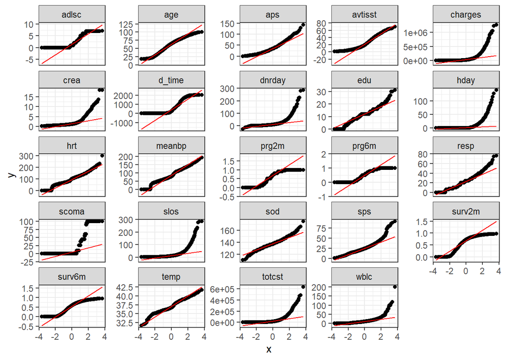

```r
long_data <- pivot_longer(numeric_predictors, cols = everything(), names_to = "variable", values_to = "value")

lda_qq_plot <- long_data %>%
  ggplot(., aes(sample = value)) +
  stat_qq() +
  geom_qq_line(color = "red") +
  facet_wrap(~variable, scales = 'free_y') +
  theme_bw()

lda_qq_plot
```

The QQ plots tend to agree with the statistical tests. However, we can see that some of the QQ plots are actually rather close to normality such as `sod`.

#### Histograms

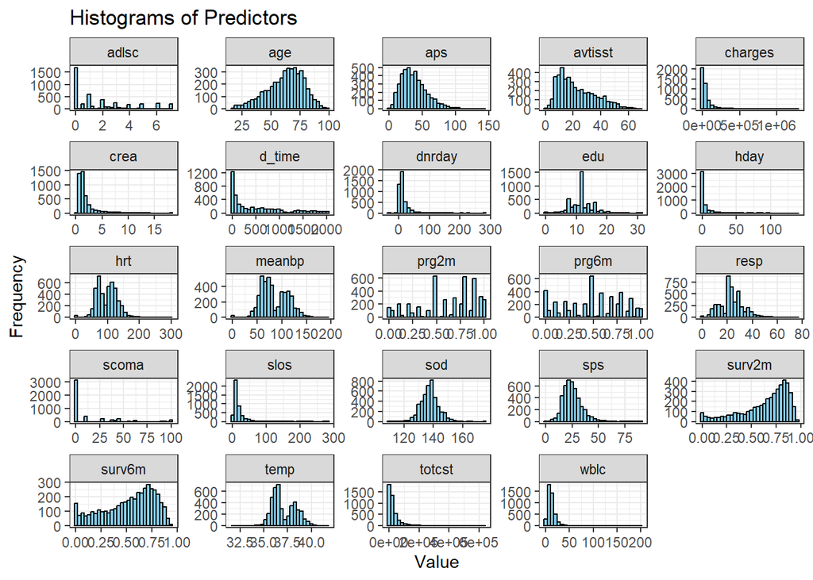

```r
lda_histogram_plot <- ggplot(long_data, aes(x = value)) +
  geom_histogram(bins = 30, fill = "skyblue", color = "black") +
  facet_wrap(~variable, scales = 'free') +
  theme_bw() +
  labs(x = "Value", y = "Frequency", title = "Histograms of Predictors")

print(lda_histogram_plot)
```

We can see that several variables are right skewed thus we will use log transformations for these to fit assumptions.

### Transformations

For transforming the data, we will use a log transformation if the skewness is greater than $1$ and use square transform if the skewness is less than $-1$. Here the skewness value is the third standardized moment:

$$\tilde\mu_3 =
\frac{E[(X-\mu)^3]}{(E[X-\mu])^{3/2}}$$

```r
for (p in 1:ncol(numeric_predictors)) {
  if (any(numeric_predictors[[p]] <= 0)) {
    cat("Predictor ", names(numeric_predictors[p]), " has 0 or negative values \n")
  }
}
```

```
## Predictor  edu  has 0 or negative values
## Predictor  scoma  has 0 or negative values
## Predictor  totcst  has 0 or negative values
## Predictor  aps  has 0 or negative values
## Predictor  surv2m  has 0 or negative values
## Predictor  surv6m  has 0 or negative values
## Predictor  prg2m  has 0 or negative values
## Predictor  prg6m  has 0 or negative values
## Predictor  dnrday  has 0 or negative values
## Predictor  meanbp  has 0 or negative values
## Predictor  wblc  has 0 or negative values
## Predictor  hrt  has 0 or negative values
## Predictor  resp  has 0 or negative values
## Predictor  adlsc  has 0 or negative values
```

Some predictors have negative values. Looking at the histograms, this is not immediately obvious. For predictors with negative or 0 values we will shift the data to the right by an amount of the absolute value of the minimum value.

```r
transform_predictors <- function(df) {
  for (p in 1:ncol(df)) {

    skewness_val <- skewness(df[[p]]) # retrieves skewness value of column

    # right skewed -> log transform
    if (skewness_val > 1){

      if (all(df[[p]] >= 0 )) { # checks if negative values
        df[[p]] <- log(df[[p]] + 1)
      } else {
        df[[p]] <- df[[p]] + abs(min(df[[p]])) + 1 # shifting the data by the minimum value amount and then adding 1 b/c cannot take log of 0
        df[[p]] <- log(df[[p]])
      }

    } else if( skewness_val < - 1) { # left skew -> square transform
      df[[p]] <- (df[[p]])^2
    }
  }

  return(df)
}

transformed_data <- transform_predictors(numeric_predictors)
```

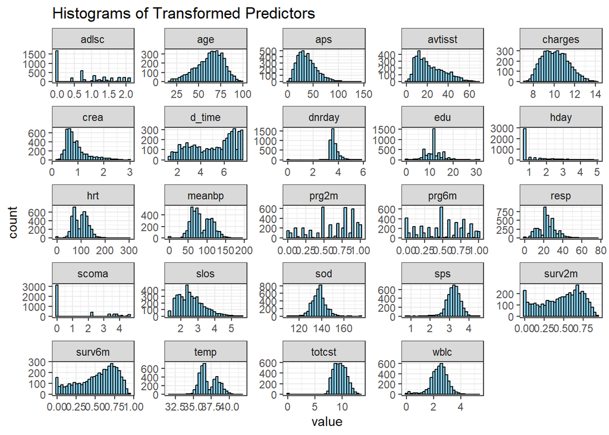

```r
# Plot histograms to check the new distributions
long_data_transformed <- pivot_longer(transformed_data, cols = everything(), names_to = "variable", values_to = "value")

lda_trans_histogram_plot <- ggplot(long_data_transformed, aes(x = value)) +
  geom_histogram(bins = 30, fill = "skyblue", color = "black") +
  facet_wrap(~variable, scales = 'free') +
  labs(title = "Histograms of Transformed Predictors") +
  theme_bw()

lda_trans_histogram_plot
```

Some plots show that the transformation was satisfactory, for instance `wblc`, however, many are still not adequately normal from a visual perspective. We will proceed nonetheless

#### QQ plot of transformed predictors

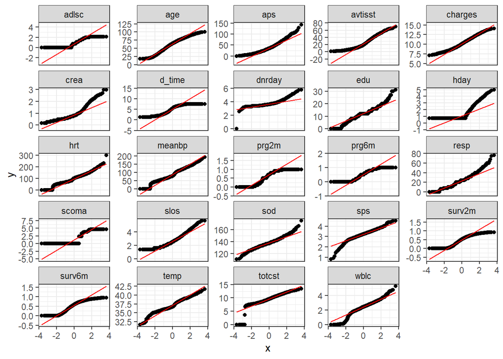

```r
lda_trans_qq_plot <- long_data_transformed %>%
  ggplot(., aes(sample = value)) +
  stat_qq() +
  geom_qq_line(color = "red") +
  facet_wrap(~variable, scales = 'free_y') +
  theme_bw()

lda_trans_qq_plot
```

As shown, the variables are certainly more normalized but not all are “normal”

### Equality of Covariance Matrices

To test for the equality of Covariance matrices, we will employ the *Box’s M test*. We will use the `biotools` library for this assumption

```r
boxM_res <- biotools::boxM(data = train_non_binary[, -1], group = train_non_binary$y)
boxM_res
```

```
##
##  Box's M-test for Homogeneity of Covariance Matrices
##
## data:  train_non_binary[, -1]
## Chi-Sq (approx.) = 24508, df = 900, p-value < 2.2e-16
```

The null hypothesis of the Box M test states that all the group covariance matrices are equal. The p-value is extremely small which leads us to rejecting the null hypothesis and concluding that the assumption of equal covariance matrices for each class is violated.

## Fitting Raw Data

Raw data includes qualitative variables one hot encoded. Some of these variables have extremely low variance which causes errors. Predictors that have near zero variance will be removed for LDA fitting purposes (causes an error otherwise).

```r
nzv <- nearZeroVar(train_data)

train_data_non0var <- train_data[, -nzv]
test_data_non0var <- test_data[, -nzv]

set.seed(32)

train_control <- trainControl(
  method = "cv",
  number = 10,
  savePredictions = "final")

lda_raw_fit <- caret::train(y ~ ., data = train_data_non0var, method = "lda", trControl = train_control)
```

```r
lda_raw_fit
```

```
## Linear Discriminant Analysis
##
## 4351 samples
##   38 predictor
##    4 classes: 'ARF/MOSF', 'Cancer', 'Coma', 'COPD/CHF/Cirrhosis'
##
## No pre-processing
## Resampling: Cross-Validated (10 fold)
## Summary of sample sizes: 3915, 3917, 3916, 3917, 3916, 3915, ...
## Resampling results:
##
##   Accuracy   Kappa
##   0.8577253  0.7818386
```

```r
pred_raw_lda <- predict(lda_raw_fit, newdata = test_data)

lda_raw_test_error <- mean(y_test != pred_raw_lda)
print(lda_raw_test_error)
```

```
## [1] 0.1345756
```

#### Confusion Matrix Raw LDA

```r
cm_raw_lda <- confusionMatrix(reference = factor(y_test), data = factor(pred_raw_lda))
cm_raw_lda
```

```
## Confusion Matrix and Statistics
##
##                     Reference
## Prediction           ARF/MOSF Cancer Coma COPD/CHF/Cirrhosis
##   ARF/MOSF                206      2   10                 20
##   Cancer                    0     64    0                  0
##   Coma                      9      1   22                  0
##   COPD/CHF/Cirrhosis       21      2    0                126
##
## Overall Statistics
##
##                Accuracy : 0.8654
##                  95% CI : (0.8317, 0.8946)
##     No Information Rate : 0.4886
##     P-Value [Acc > NIR] : < 2.2e-16
##
##                   Kappa : 0.7906
##
##  Mcnemar's Test P-Value : NA
##
## Statistics by Class:
##
##                      Class: ARF/MOSF Class: Cancer Class: Coma
## Sensitivity                   0.8729        0.9275     0.68750
## Specificity                   0.8704        1.0000     0.97783
## Pos Pred Value                0.8655        1.0000     0.68750
## Neg Pred Value                0.8776        0.9881     0.97783
## Prevalence                    0.4886        0.1429     0.06625
## Detection Rate                0.4265        0.1325     0.04555
## Detection Prevalence          0.4928        0.1325     0.06625
## Balanced Accuracy             0.8717        0.9638     0.83266
##                      Class: COPD/CHF/Cirrhosis
## Sensitivity                             0.8630
## Specificity                             0.9318
## Pos Pred Value                          0.8456
## Neg Pred Value                          0.9401
## Prevalence                              0.3023
## Detection Rate                          0.2609
## Detection Prevalence                    0.3085
## Balanced Accuracy                       0.8974
```

```r
cm_raw_lda_table <- cm_raw_lda$table

tpr <- fpr <- tnr <- fnr <- numeric(4)

for (i in 1:4) {
  tp <- cm_raw_lda_table[i, i]
  fn <- sum(cm_raw_lda_table[i,]) - tp
  fp <- sum(cm_raw_lda_table[,i]) - tp
  tn <- sum(cm_raw_lda_table) - (tp + fn + fp)

  tpr[i] <- tp / (tp + fn)  # True Positive Rate
  fpr[i] <- fp / (fp + tn)  # False Positive Rate
  tnr[i] <- tn / (tn + fp)  # True Negative Rate
  fnr[i] <- fn / (fn + tp)  # False Negative Rate
}

# Print the results
cat("True Positive Rates (TPR):", tpr, "\n",
    "False Positive Rates (FPR):", fpr, "\n",
    "True Negative Rates (TNR):", tnr, "\n",
    "False Negative Rates (FNR):", fnr, "\n")
```

```
## True Positive Rates (TPR): 0.8655462 1 0.6875 0.8456376
##  False Positive Rates (FPR): 0.122449 0.01193317 0.02217295 0.05988024
##  True Negative Rates (TNR): 0.877551 0.9880668 0.9778271 0.9401198
##  False Negative Rates (FNR): 0.1344538 0 0.3125 0.1543624
```

## Fitting Original Non-Binary Data

```r
# numeric predictors data
train_non_binary <- train_data %>% select_if(~length(unique(.)) > 2)
test_non_binary <- test_data %>% select_if(~length(unique(.)) > 2)

nzv_non_binary <- nearZeroVar(train_non_binary)

train_non_binary_non0var <- train_non_binary[, -nzv_non_binary]
test_non_binary_non0var <- test_non_binary[, -nzv_non_binary]

set.seed(32)

train_control <- trainControl(
  method = "cv",
  number = 10,
  savePredictions = "final"
)

lda_fit <- caret::train(y ~ ., data = train_non_binary, method = "lda", trControl = train_control) # trained on train split
```

```r
lda_fit
```

```
## Linear Discriminant Analysis
##
## 4351 samples
##   24 predictor
##    4 classes: 'ARF/MOSF', 'Cancer', 'Coma', 'COPD/CHF/Cirrhosis'
##
## No pre-processing
## Resampling: Cross-Validated (10 fold)
## Summary of sample sizes: 3915, 3917, 3916, 3917, 3916, 3915, ...
## Resampling results:
##
##   Accuracy   Kappa
##   0.8436996  0.76064
```

```r
pred_test_lda <- predict(lda_fit, newdata = test_non_binary)

y_test_nb <- test_non_binary$y

lda_test_error <- sum(y_test_nb != pred_test_lda) / length(y_test_nb)


print(lda_test_error)
```

```
## [1] 0.1614907
```

#### Confusion Matrix

```r
cm_lda <- confusionMatrix(reference = factor(y_test), data = factor(pred_test_lda))
cm_lda
```

```
## Confusion Matrix and Statistics
##
##                     Reference
## Prediction           ARF/MOSF Cancer Coma COPD/CHF/Cirrhosis
##   ARF/MOSF                196      3   11                 20
##   Cancer                    0     63    0                  1
##   Coma                     10      0   21                  0
##   COPD/CHF/Cirrhosis       30      3    0                125
##
## Overall Statistics
##
##                Accuracy : 0.8385
##                  95% CI : (0.8026, 0.8702)
##     No Information Rate : 0.4886
##     P-Value [Acc > NIR] : < 2.2e-16
##
##                   Kappa : 0.7497
##
##  Mcnemar's Test P-Value : NA
##
## Statistics by Class:
##
##                      Class: ARF/MOSF Class: Cancer Class: Coma
## Sensitivity                   0.8305        0.9130     0.65625
## Specificity                   0.8623        0.9976     0.97783
## Pos Pred Value                0.8522        0.9844     0.67742
## Neg Pred Value                0.8419        0.9857     0.97566
## Prevalence                    0.4886        0.1429     0.06625
## Detection Rate                0.4058        0.1304     0.04348
## Detection Prevalence          0.4762        0.1325     0.06418
## Balanced Accuracy             0.8464        0.9553     0.81704
##                      Class: COPD/CHF/Cirrhosis
## Sensitivity                             0.8562
## Specificity                             0.9021
## Pos Pred Value                          0.7911
## Neg Pred Value                          0.9354
## Prevalence                              0.3023
## Detection Rate                          0.2588
## Detection Prevalence                    0.3271
## Balanced Accuracy                       0.8791
```

```r
cm_lda_table <- cm_lda$table

tpr <- fpr <- tnr <- fnr <- numeric(4)

for (i in 1:4) {
  tp <- cm_lda_table[i, i]
  fn <- sum(cm_lda_table[i,]) - tp
  fp <- sum(cm_lda_table[,i]) - tp
  tn <- sum(cm_lda_table) - (tp + fn + fp)

  tpr[i] <- tp / (tp + fn)  # True Positive Rate
  fpr[i] <- fp / (fp + tn)  # False Positive Rate
  tnr[i] <- tn / (tn + fp)  # True Negative Rate
  fnr[i] <- fn / (fn + tp)  # False Negative Rate
}

# Print the results
cat("True Positive Rates (TPR):", tpr, "\n",
    "False Positive Rates (FPR):", fpr, "\n",
    "True Negative Rates (TNR):", tnr, "\n",
    "False Negative Rates (FNR):", fnr, "\n")
```

```
## True Positive Rates (TPR): 0.8521739 0.984375 0.6774194 0.7911392
##  False Positive Rates (FPR): 0.1581028 0.01431981 0.02433628 0.06461538
##  True Negative Rates (TNR): 0.8418972 0.9856802 0.9756637 0.9353846
##  False Negative Rates (FNR): 0.1478261 0.015625 0.3225806 0.2088608
```